# Guaidó and Maduro’s Tweets - Venezuela

Luis Noguera

2/6/2019

### Venezuela’s Context for the Analysis.

Venezuela’s current political situation is more unstable than ever. On one side Nicolás Maduro, sucessor of the deceased president Hugo Chávez since 2013. Maduro has been accused of being a dictator for it’s abusive manners to suppress popular demonstrations, violate human rights and imprison many opposition leaders.

On the other side a young charismatic leader, Juan Guaidó, he has been able to unified a divided opposition. Guaidó became the head of the opposition-held parliament, the National Assembly in early January 2019. Even if Maduro stripped the legislative elective body of its powers, the Parliament has been recognized by the internaional community.

According to the Venezuelan constitution, the National Assembly leader becomes president whenever there is a “vacuum of power” within the country. Guaidó claims Maduro’s second term, won through rigged elections in May 2018, constitutes such a vacuum. This makes Guaidó the legitimate interim president of Venezuela, Guaido has been recognized by many countries in the region, USA and more than 45 countries around the world.

Let’s dig into the activity of these two political party leaders in Twitter. I want to look at their Twitter activity, characteristic words and their rhetoric in Twitter using text analytics.

### Setting Up Twitter API

```r
library(twitteR)
library(tm)
#to get your consumerKey and consumerSecret see the twitteR documentation for instructions
consumer_key <- 'ZMLi95f8HIadbzJoiPMUen6Pt'
consumer_secret <- 'jd4knD5QhlLcrsckq1Ped8VUngHXXiT133bxXydwgKes1GHM7Y'
access_token <- '326493198-oqFgXpXpjoWHbbqDlWRjUyOnWapirsMQfVFgUQFx'
access_secret <- '3JJgxAxQ3MKxqRS5KEAEqbaqViXWW2nREhC4Pa4KHgGhJ'
setup_twitter_oauth(consumer_key, consumer_secret, access_token, access_secret)
```

### Downloading tweets from both users

Downloading the tweets from the two official user accounts of Juan Guaido (@jguaido) and Nicolas Maduro (@NicolasMaduro). 3200 tweets have been downloaded for both, this is the maximum amount that can be downloaded with using the Twitter API and userTimeline.

```r
# Downloading tweets
guaido <- twitteR::userTimeline('jguaido', n=3200, includeRts = TRUE) #Downloading tweets from Juan Guaido
guaido_df = twitteR::twListToDF(guaido) # converting tweets into a DataFrame
write.csv(guaido_df, file='/Users/luisnoguera/Desktop/Hult /Module A BAN/Module B BAN/Text Analytics/Venezuela Twitter Sentiment/Two Leaders/guaido2.csv') # Saving Tweets into a csv file for
# Repeating process with Nicolas Maduro tweets
maduro <- twitteR::userTimeline('NicolasMaduro', n=3200, includeRts = TRUE) #Downloading tweets from Nicolas Maduro
maduro_df = twitteR::twListToDF(maduro)
write.csv(maduro_df, file='/Users/luisnoguera/Desktop/Hult /Module A BAN/Module B BAN/Text Analytics/Venezuela Twitter Sentiment/Two Leaders/maduro.csv') # Saving Tweets into a csv file
```

#### Binding both Dataframes

```r
library(dplyr)
library(tidytext)
library(tidyr)

tweets <- bind_rows(
  maduro_df %>%
    mutate(person = 'Nicolás Maduro') %>% # Creating a new column for identificaion
    filter(isRetweet==F) %>%  # Filter retweets because I only want tweets written by the user
    select(text, screenName, created, retweetCount, favoriteCount, person),
  guaido_df %>%
    mutate(person = 'Juan Guaidó') %>% # Creating a new column for identificaion
    filter(isRetweet==F) %>% # Filter retweets because I only want tweets written by the user
    select(text, screenName, created, retweetCount, favoriteCount, person)) %>%
  mutate(created = ymd_hms(created)) # Modifying date format
```

### Twitter Activity 2018-2019

Let’s take a look to the posting habits of these two users. How often they post and how active they are on Twitter.

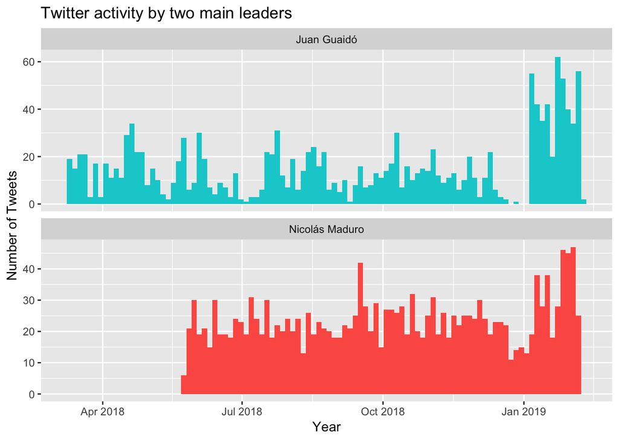

```r
library(ggplot2)

ggplot(tweets, aes(x = created, fill = person)) +
  geom_histogram(
    position = "identity", bins = 100, show.legend = FALSE) +
  facet_wrap(~person, ncol = 1, scales = "free_y") +
  ggtitle("Twitter activity by two main leaders") +
  xlab("Year") +
  ylab("Number of Tweets") +
  scale_fill_manual(values=c("#00ced1", "#fd5e53"))
```

**Insights**

Juan Guaido’s activity in Twitter has been lower compared to Nicolas Maduro in 2018. However, an important spike is shown at the beginning of 2019 for both users, specially for Juan Guaidó who gained immense public exposure by leading the opposition party in the Legislative Assembly this year.

If you questioned why there is no data from Nicolas Maduro before June 2018, it is because the maximum amount of tweets that can be downloaded has been reached and there is no tweets information from that period.

### Data Cleaning

Here I am removing all punctuations, hashtags and possible mentions in the tweet text. Also removing stop_words or common words of the language. I had to customise these steps since all the text was in spanish.

```r
# Cleaning the text from website links and irregular signs
replace_reg <- "http[s]?://[A-Za-z\\d/\\.]+|&amp;|&lt;|&gt;"
unnest_reg  <- "([^A-Za-z_\\d#@']|'(?![A-Za-z_\\d#@]))"
custom_stop_words <- bind_rows(stop_words,
                               data_frame(word = tm::stopwords("spanish"),
                                          lexicon = "custom"))  # Custom spanish stop_words
# Tokenizing the texts from tweets
tidy_tweets <- tweets %>%
  filter(!str_detect(text, "^RT|@")) %>%
  mutate(text = str_replace_all(text, replace_reg, "")) %>%
  mutate(id = row_number()) %>%
  unnest_tokens(word, text) %>%
  filter(!word %in% custom_stop_words$word, str_detect(word, "[a-z]"))
```

### Comparing Words Used by Maduro and Guaidó

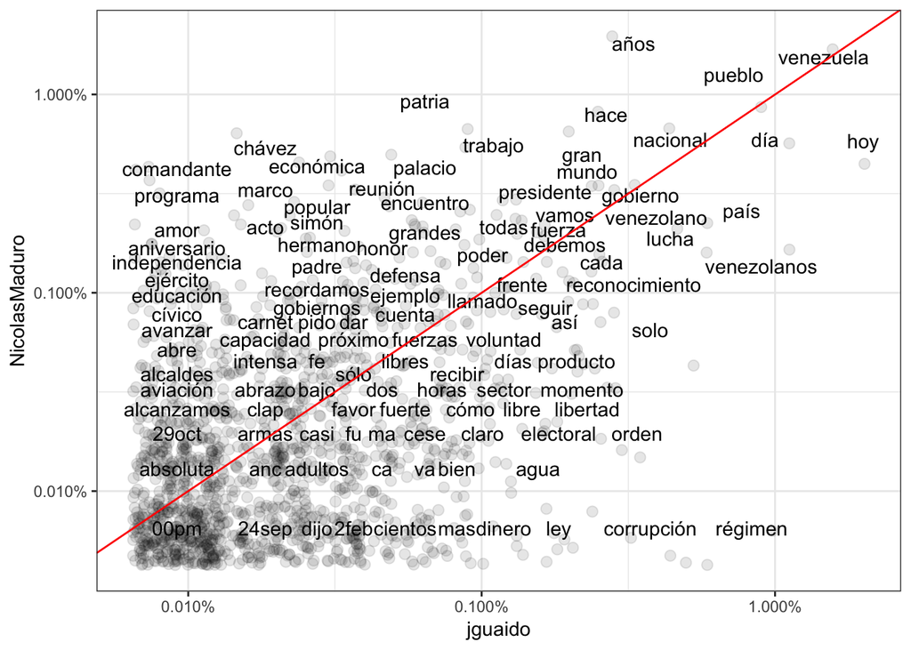

```r
# Word frequency comparison
frequency <- tidy_tweets %>%
  group_by(screenName) %>%
  count(word, sort = TRUE) %>%
  left_join(tidy_tweets %>%
              group_by(screenName) %>%
              summarise(total = n())) %>%
  mutate(freq = n/total)
frequency.spread <- frequency %>%
  select(screenName, word, freq) %>%
  spread(screenName, freq) %>%
  arrange(desc(jguaido), desc(NicolasMaduro))
ggplot(frequency.spread, aes(jguaido, NicolasMaduro)) +
  geom_jitter(
    alpha = 0.1, size = 2.5, width = 0.15, height = 0.15) +
  geom_text(aes(label = word), check_overlap = TRUE, vjust = 0) +
  scale_x_log10(labels = percent_format()) +
  scale_y_log10(labels = percent_format()) +
  geom_abline(color = "red") + theme_bw()
```

**Insights**

Maduro uses particular inclusive words such as: love, victory, life, capacity and cooperation to speak to its followers. These words are barely found in Guaidó’s tweets. The later one, uses words to denounce and descredit Maduro such as: dictatorship, regime, crisis.

In the middle red line can be found words that are probable to be found in both users feed in equal frequency such as, Venezuela, Venezuelans, strength and government.

#### Top 15 characteristic words by each user

This graph displays the top 15 characteristic words used by both users.

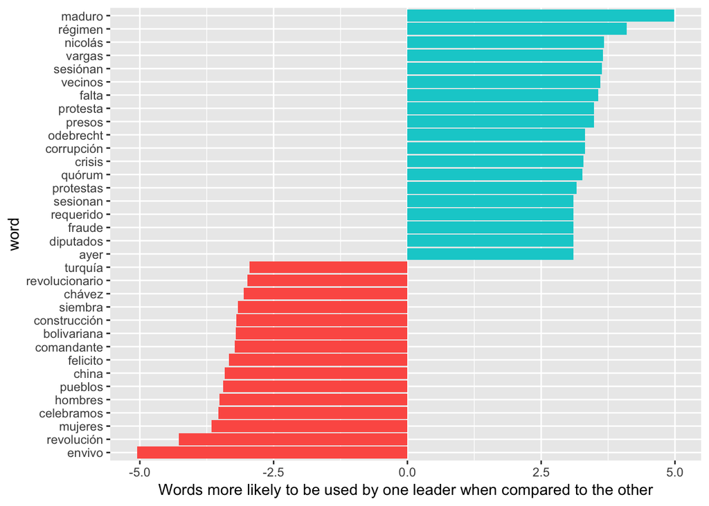

```r
word_ratios <- tidy_tweets %>%
  filter(!str_detect(word, "^@")) %>%
  count(word, screenName) %>%
  filter(sum(n) >= 10) %>%
  ungroup() %>%
  spread(screenName, n, fill = 0) %>%
  mutate_if(is.numeric, funs((. + 1) / sum(. + 1))) %>%
  mutate(logratio = log(jguaido / NicolasMaduro)) %>%
  arrange(desc(logratio))
word_ratios %>%
  group_by(logratio < 0) %>%
  top_n(15, abs(logratio)) %>%
  ungroup() %>%
  mutate(word = reorder(word, logratio)) %>%
  ggplot(aes(word, logratio, fill = logratio < 0)) +
  geom_col(show.legend = FALSE) +
  coord_flip() +
  ylab("Words more likely to be used by one leader when compared to the other") +
  scale_fill_discrete(name = "", labels = c("Nicolas Maduro", "Juan Guaido")) +
  scale_fill_manual(values=c("#00ced1", "#fd5e53"))
```

**Insights**

One aspect that surprised me is that Juan Guaidó makes direct reference to Maduro, calling him by his name and last name, I will discuss this strategy later on in the analysis.

Furthermore, I did not know why the state Vargas is found in the top of the list for Guaidó, a quick manual search on his tweets and online provided me the answer, I discovered that Vargas it’s his place of birth, the state that chose him as legislator and where he employs most of his political efforts helping people. Other words are particularly interesting where he is clearly denouncing the crisis lived in Venezuela, corruption, fraud and imprisonment of peers in Maduro’s regime.

Nicolas Maduro most characteristic words make reference to live events he is attending, makes reference to Chavez revolution, celebration of national, congratulating his people and mentioning historic national dates on Twitter.

### Change in words tweeted over time.

Let’s take a look at important changes in words used by the two of them.

#### Nicolás Maduro

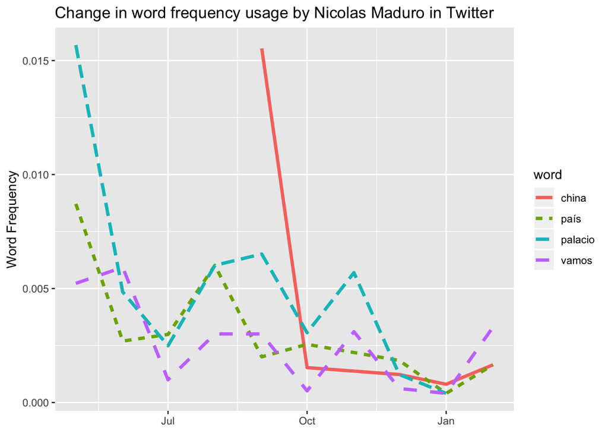

```r
words_by_time <- tidy_tweets %>%
  filter(!str_detect(word, "^@")) %>%
  mutate(time_floor = floor_date(created, unit = "1 month")) %>%
  count(time_floor, screenName, word) %>%
  ungroup() %>%
  group_by(screenName, time_floor) %>%
  mutate(time_total = sum(n)) %>%
  group_by(word) %>%
  mutate(word_total = sum(n)) %>%
  ungroup() %>%
  rename(count = n) %>%
  filter(word_total > 30)

nested_data <- words_by_time %>%
  nest(-word, -screenName)

nested_models <- nested_data %>%
  mutate(models = map(data, ~ glm(cbind(count, time_total)~time_floor,.,
                                  family= 'binomial')))

slopes <- nested_models %>%
  unnest(map(models, tidy)) %>%
  filter(term == "time_floor") %>%
  mutate(adjusted.p.value = p.adjust(p.value))

top_slopes <- slopes %>%
  filter(adjusted.p.value < 0.7) %>%
  select(-statistic, -p.value)

# Trending words and changes in Nicolas Maduro's Tweets
words_by_time %>%
  inner_join(top_slopes, by = c("word", "screenName")) %>%
  filter(screenName == "NicolasMaduro") %>%
  ggplot(aes(time_floor, count/time_total, color = word, lty = word)) +
  geom_line(size = 1.3) +
  labs(x = NULL, y = "Word Frequency") +
  ggtitle('Change in word frequency usage by Nicolas Maduro in Twitter')
```

**Insights**

The main word that shows an important decline is China, it was mentioned a lot in September so I decided to look into it. What I found is that during the middle and end of September, Maduro traveled to China, one of Venezuela main creditors for what Mauduro announced was going to be an important meeting in the economic sphere.

#### Juan Guaidó

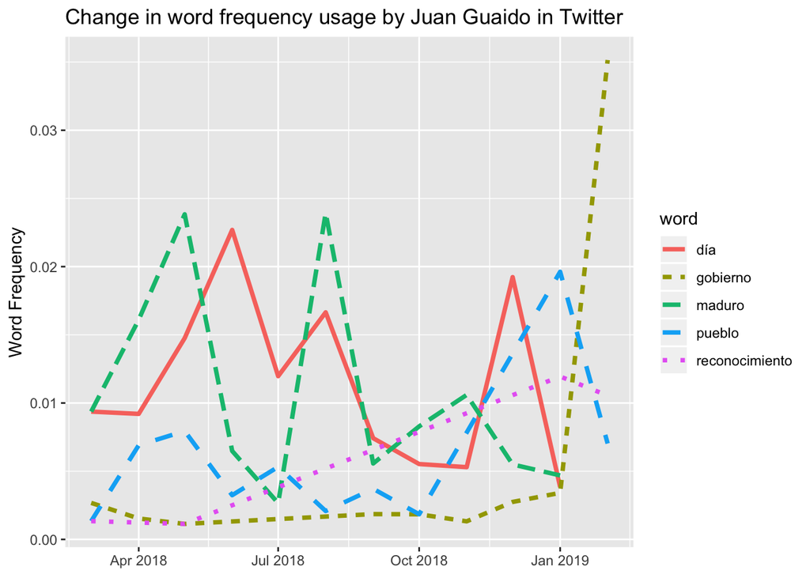

```r
# Trending words and changes in Juan Guaido's Tweets
words_by_time %>%
  inner_join(top_slopes, by = c("word", "screenName")) %>%
  filter(screenName == "jguaido") %>%
  ggplot(aes(time_floor, count/time_total, color = word, lty = word)) + geom_line(size = 1.3) +
  labs(x = NULL, y = "Word Frequency") +
  ggtitle('Change in word frequency usage by Juan Guaido in Twitter')
```

**Insights**

On Guaido’s side, we can see an important climb at the beginning of 2019 for the “government”. Which makes sense due to the government transition attempt that he is leading since the beginning of the year.

More importantly, I see a decline in the use of the word “Maduro”, which I consider a sensible one. Should he keep using his name directly? Should he find different ways to reference to him?

### Retweets and Favorited Words

#### Words retweeted more often

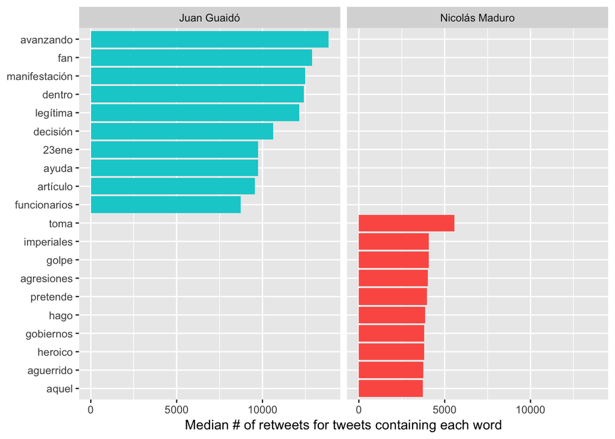

```r
# Words with highest median retweets

totals <- tidy_tweets %>%
  group_by(person, id) %>%
  summarise(rts = sum(retweetCount)) %>%
  group_by(person) %>%
  summarise(total_rts = sum(rts))

word_by_rts <- tidy_tweets %>%
  group_by(id, word, person) %>%
  summarise(rts = first(retweetCount)) %>%
  group_by(person, word) %>%
  summarise(retweetCount = median(rts), uses = n()) %>%
  left_join(totals) %>%
  filter(retweetCount != 0) %>%
  ungroup()

word_by_rts %>%
  filter(uses >= 5) %>%
  group_by(person) %>%
  top_n(10, retweetCount) %>%
  arrange(retweetCount) %>%
  ungroup() %>%
  mutate(word = factor(word, unique(word))) %>% ungroup() %>%
  ggplot(aes(word, retweetCount, fill = person)) +
  geom_col(show.legend = FALSE) +
  facet_wrap(~ person, ncol = 2) +
  coord_flip() +
  labs(x = NULL,
       y = "Median # of retweets for tweets containing each word") +
  scale_fill_manual(values=c("#00ced1", "#fd5e53"))
```

**Insights**

At first, we can clearly see that the amount of retweets received Juan Guaidó surpasses by far the ones of Maduro. A clear sign of the world wide popularity of Guaidó.

Let’s now dive into those words that receive more retweets than others. “Avanzando” or “moving forward” by Juan Guaidó clearly leads the retweeted tweets, an evident sign of aspiration and hope by Guaidó’s followers.

#### Words favorited more often

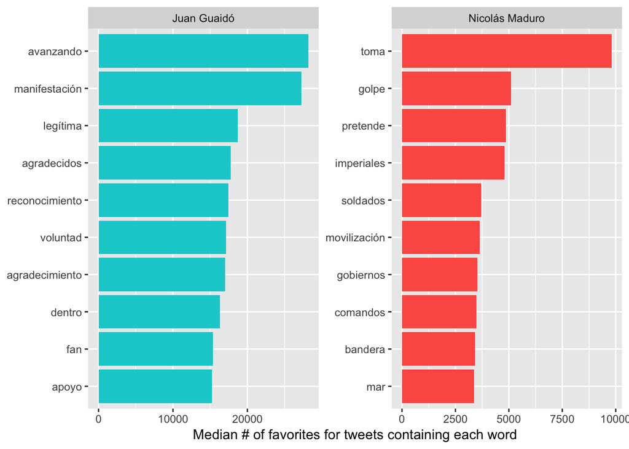

**Insights**

Finally, the words that are found more frequently in favorited tweets. There is not much difference to the tweets and words that get retweeted more often, which suggest that people retweeting also mark these tweets as favorite.